# Differentially-Expressed Gene Analysis

hongc2@ccf.org

1/16/2020

### Setup

Let us setup the experiment by loading the previous R environment files and R libraries if not exist.

```r
library(data.table)
library(ggplot2)
library(cowplot)
library(Seurat)

load('out/02_immune_cons.rd') #immune.combined
```

### Identify differential expressed genes across conditions

Now that we’ve aligned the stimulated and control cells, we can start to do comparative analyses and look at the differences induced by stimulation. One way to look broadly at these changes is to plot the average expression of both the stimulated and control cells and look for genes that are visual outliers on a scatter plot. Here, we take the average expression of both the stimulated and control naive T cells and CD14 monocyte populations and generate the scatter plots, highlighting genes that exhibit dramatic responses to interferon stimulation.

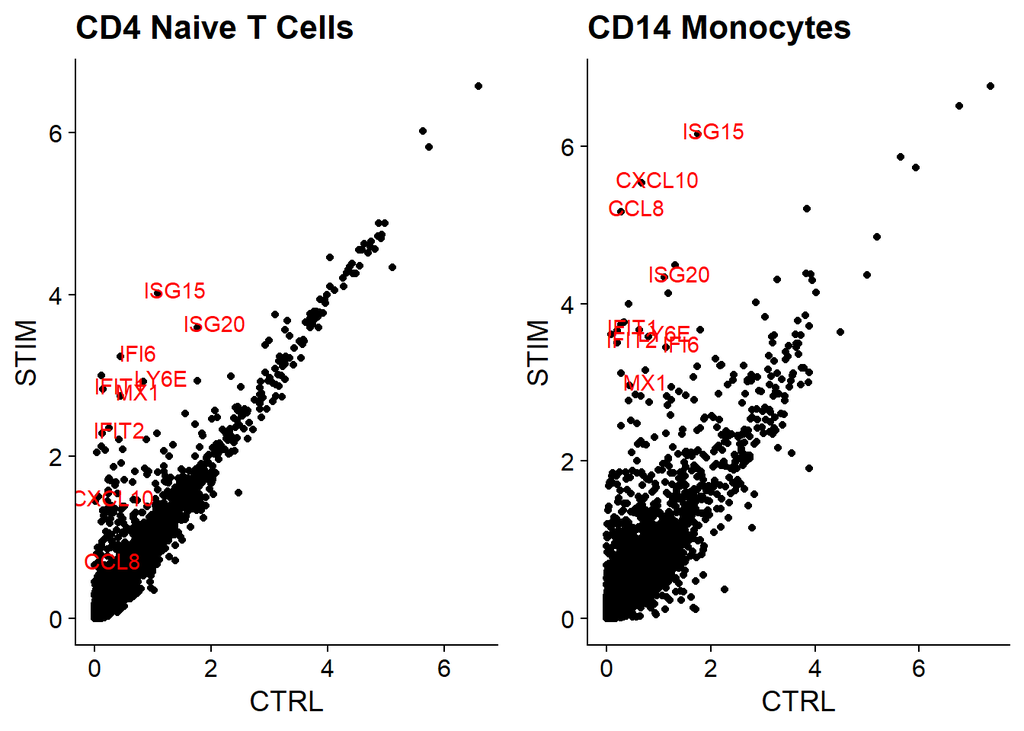

```r
DefaultAssay(immune.combined) <- "RNA"

theme_set(theme_cowplot())
t.cells <- subset(immune.combined, idents = "CD4 Naive T")
Idents(t.cells) <- "stim"
avg.t.cells <- log1p(AverageExpression(t.cells, verbose = FALSE)$RNA) #the default slot is .data which was normalized in the prev step!
avg.t.cells$gene <- rownames(avg.t.cells)

cd14.mono <- subset(immune.combined, idents = "CD14 Mono")
Idents(cd14.mono) <- "stim"
avg.cd14.mono <- log1p(AverageExpression(cd14.mono, verbose = FALSE)$RNA)
avg.cd14.mono$gene <- rownames(avg.cd14.mono)

genes.to.label = c("ISG15", "LY6E", "IFI6", "ISG20", "MX1", "IFIT2", "IFIT1", "CXCL10", "CCL8")
p1 <- ggplot(avg.t.cells, aes(CTRL, STIM)) + geom_point() + ggtitle("CD4 Naive T Cells")
p1 <- LabelPoints(plot = p1, points = genes.to.label, repel = FALSE, colour="red")
p2 <- ggplot(avg.cd14.mono, aes(CTRL, STIM)) + geom_point() + ggtitle("CD14 Monocytes")
p2 <- LabelPoints(plot = p2, points = genes.to.label, repel = FALSE, colour="red")
plot_grid(p1, p2)
```

### Differential expression gene analysis between two samples

As you can see, many of the same genes are upregulated in both of these cell types and likely represent a conserved interferon response pathway.

Because we are confident in having identified common cell types across the condition, we can ask what genes change in different conditions for cells of the same type. First, we create a column in the meta.data slot to hold both the cell type and stimulation information and switch the current ident to that column. Then we use `FindMarkers` to find the genes that are different between stimulated and control B cells. Notice that many of the top genes that show up here are the same as the ones we plotted earlier as core interferon response genes. Additionally, genes like *CXCL10* which we saw were specific to monocyte and B cell interferon response show up as highly significant in this list as well.

```r
immune.combined$celltype.stim <- paste(Idents(immune.combined), immune.combined$stim, sep = "_")
Idents(immune.combined) <- "celltype.stim"

# If you want more rigorous DGE analysis, you can use RNA.count and ZINB (zero-inflation negative binomial) as a test model.
b.interferon.response <- FindMarkers(immune.combined, ident.1 = "B_STIM", ident.2 = "B_CTRL", verbose = FALSE)
head(b.interferon.response, n = 15)
```

```
##                 p_val avg_logFC pct.1 pct.2     p_val_adj
## ISG15   5.387767e-159 3.2053742 0.998 0.233 7.571429e-155
## IFIT3   1.945114e-154 3.1250966 0.965 0.052 2.733468e-150
## IFI6    2.503565e-152 2.9325755 0.965 0.076 3.518260e-148
## ISG20   6.492570e-150 2.0373399 1.000 0.668 9.124009e-146
## IFIT1   1.951022e-139 2.8645627 0.907 0.029 2.741772e-135
## MX1     6.897626e-123 2.2571348 0.905 0.115 9.693234e-119
## LY6E    2.825649e-120 2.1597818 0.898 0.150 3.970885e-116
## TNFSF10 4.007285e-112 2.6378243 0.786 0.020 5.631437e-108
## IFIT2   2.672552e-108 2.5226736 0.786 0.037 3.755738e-104
## B2M      5.283684e-98 0.4219851 1.000 1.000  7.425161e-94
## PLSCR1   4.634658e-96 1.9730793 0.793 0.113  6.513085e-92
## IRF7     2.411149e-94 1.8012358 0.835 0.187  3.388388e-90
## CXCL10   3.708508e-86 3.6838772 0.651 0.010  5.211566e-82
## UBE2L6   5.547472e-83 1.4893574 0.851 0.297  7.795863e-79
## PSMB9    1.716262e-77 1.1333816 0.937 0.568  2.411863e-73
```

### Gene expression level in UMAP or Violin Plot

Another useful way to visualize these changes in gene expression is with the option `split.by` the `FeaturePlot` or `VlnPlot` function. This will display `FeaturePlots` of the list of given genes, split by a grouping variable (stimulation condition here). Genes such as *CD3D* and *GNLY* are canonical cell type markers (for T cells and NK/CD8 T cells) that are virtually unaffected by interferon stimulation and display similar gene expression patterns in the control and stimulated group. *IFI6* and *ISG15*, on the other hand, are core interferon response genes and are upregulated accordingly in all cell types. Finally, *CD14* and *CXCL10* are genes that show a cell type-specific interferon response. *CD14* expression decreases after stimulation in *CD14* monocytes, which could lead to misclassification in a supervised analysis framework, underscoring the value of integrated analysis. *CXCL10* shows a distinct upregulation in monocytes and B cells after interferon stimulation but not in other cell types.

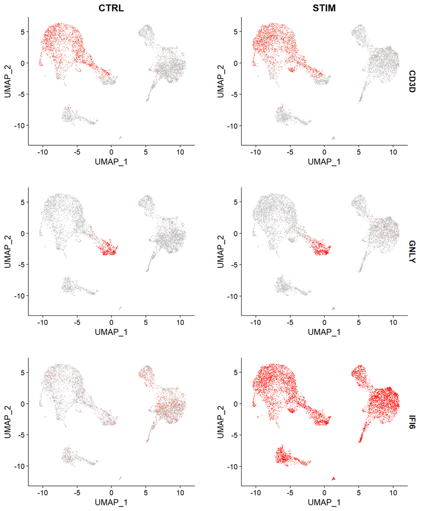

```r
FeaturePlot(immune.combined,
            features = c("CD3D", "GNLY", "IFI6"),
            split.by = "stim",
            max.cutoff = 3,
            cols = c("grey", "red"))
```

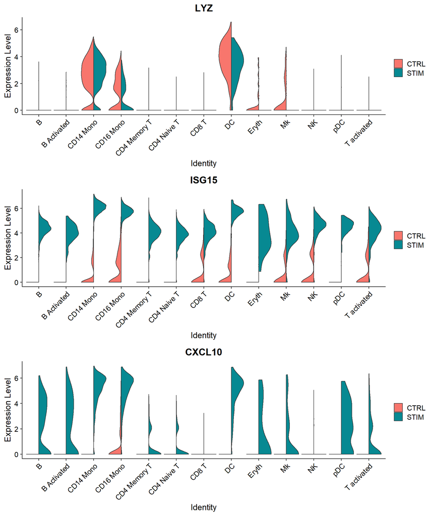

```r
plots <- VlnPlot(immune.combined,
                 features = c("LYZ", "ISG15", "CXCL10"),
                 split.by = "stim",
                 group.by = "seurat_annotations",
                 pt.size = 0,
                 combine = FALSE)

CombinePlots(plots = plots, ncol = 1)
```

### Things to explore more

- Pseudo time analysis (Slingshot)
- ZINB DGE analysis (DEsingle)
- Functional enrichment analysis (GSEA)